# Sprawozdanie 2

Karol Szpyt

7 kwietnia 2018

## Wstęp

Praca składała się bedzie z dwóch części:

- **I** - Analiza mocy testów normalności
- **II** - Analiza mocy testu Wilcoxona

# Użyte pakiety

```r
library(dplyr)
library(tseries)
library(ggplot2)
library(reshape2)
```

# Funkcje

Funkcja “rmix” tworzy **n**-elementowy rozkład będący mieszanką dwóch innych rozkładów (**family_1**, **family_2**) o parametrach (**par_1**, **par_2**). **p** jest prawdopodobieństwem wystąpienia **pierwszego** typu rozkładu. Pamiętać trzeba, że mieszanka rozkładów normalnych o różnych parametrach **nie jest** rozkładem normalnym!

```r
rmix <- function(n, family_1, par_1, family_2, par_2, p)
{
  pp <- sample(c(1,2), n, replace = TRUE, prob = c(p, 1-p))
  n1 <- length(pp[pp==1])
  n2 <- length(pp[pp==2])

  eval(parse(text = paste0("fun1 <- r", family_1)))
  r1 <- do.call(fun1, as.list(c(n1, par_1)))

  eval(parse(text = paste0("fun2 <- r", family_2)))
  r2 <- do.call(fun2, as.list(c(n2, par_2)))

  return(c(r1,r2))
}
```

Funckja ctp jako argument przyjmuje **datalist**, który jest listą zawierającą daną ilość n-elementowych prób, na podstawie której wyliczana jest moc testów Shapiro-Wilka, Kołmogorowa-Smirnowa oraz Jarque-Bera. Przyjmujemy hipotezy:  
>$H_0$: Badany rozkład jest rozkładem normalnym  
>$H_1$: Badany rozkład **nie** jest rozkładem normlanym

```r
ctp <- function(datalist){

  a <- sapply(datalist, function(x)
  {
    shapiro.test(x)$p.value
  })

  b <- sapply(datalist, function(x)
  {
    ks.test(x, pnorm)$p.value
  })

  c <- sapply(datalist, function(x)
  {
    jarque.bera.test(x)$p.value
  })

  sw <- mean(a < 0.05)
  ks <- mean(b < 0.05)
  jb <- mean(c < 0.05)

  r <- tibble(sw_test = sw, ks_test = ks, jb_test = jb)

  return(r)
}
```

Funckja ctp_wx jako argument przyjmuje **datalist1** oraz **datalist2** które są listami zawierającymi daną ilość n-elementowych prób, na podstawie których wyliczana jest moc testu Wilcoxona.  
Test Wilcoxona przyjmuje następujące hipotezy:  
>$H_0$: Me1 = Me2  
>$H_1$: Me1 != Me2

```r
ctp_wx <- function(datalist1, datalist2){

  a <- mapply(function(x, y)
  {
    wilcox.test(x, y, paired = T)$p.value
  }, datalist1, datalist2)

  wx <- mean(a < 0.05)

  r <- tibble(wx_test = wx)

  return(r)
}
```

Przykład budowy takiej listy:

```r
lapply(rep("a", 3), function(x){
    rnorm(5)
  })
```

```
## [[1]]
## [1]  0.9326155 -0.6734985  2.0691787 -0.4960630 -1.7084715
##
## [[2]]
## [1]  0.4303100  0.7763469  0.2719765 -0.9357379  0.2278123
##
## [[3]]
## [1] -0.2974595 -0.6804148  0.1658736  1.8569978 -0.3274715
```

Powyższy zapis pozwolił na stworzenie 3 elementowej tablicy, gdzie każdy z elementów to 5 wartości rozkładu normalnego standardowego.

## Analiza mocy testów normalności

Badanie ma na celu zobrazowanie mocy testów normalności (**Shapiro-Wilka**, **Kołmogorowa-Smirnowa** oraz **Jarque-Bera**), na podstawie danych wygenerowanych za pomocą funkcji rmix, w zależności od parametrów przyjmowanych przez tą funkcję(**mn** oraz **sd**), długość próbki **len** oraz prawdopodobieństwa wystąpienia pierwszego rozkładu **prob**.

```r
#ilość prób
n <- 1000
#długość próbki
len <- c(100, 1000, 5000)
#pierwszy rodzaj rozkładu
d1 <- "norm"
#pierwsze parametry
#p1 <- c(0, 1)#10 000, 50
mn <- c(0, 10, 500, 1000, 10000)
sd <- c(1, 10, 500, 1000, 10000)
#drugi rodzaj rozkładu
d2 <- "norm"
#drugie parametry
p2 <- c(500, 500)#1000, 500
#prawdopodobieństwo wystąpienia pierwszego rozkładu
prob <- seq(0, 1, 0.1)
```

Ilość symulacji ustawiona została ustawiona na wysoką wartość równą 1000

Poniższe wykresy obrazują zmiany mocy (**OY**) testów normalności w zależności od prawdopodobieństwa wystąpienia **pierwszego** rozkładu (**OX**), **wartości oczekwianej**, **odchylenia standardowego** oraz **długości próby**, widoczne kolejno na każdym z pasków. Rozkład “po lewej” ma statycznie ustawione parametry (**N(500, 500)**), a rozkład “po prawej stronie” zmienia się tak jak widoczne jest to powyżej.

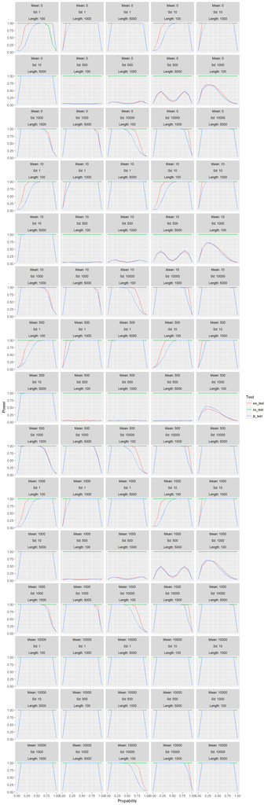

Tak jak widać na powyższych wykresach wartości skrajne dla zmiennej **Propability** drastycznie spadają. Jest to spowodawne tym, że im wartość bliższa jest zeru lub jedynce tym bardziej dany rozkład przypominał będzie rozkład normalny o danych parametrach.  
Wzrost **długości próby** (trzecia wartość na pasku) niweluje błąd losowy, przez co wykresy są “wygładzone”.  
Im bardziej, dwa zmieszane ze sobą rozkłady, się od siebie **różnią**, tym wyższa jest moc testów istotności. Spowodowane to jest tym, że pomieszanie dwóch rozkładów normalnych o różnych parametrach nie daje rozkładu normalnego. Im rozkłady są do siebie bardziej zbliżone tym moc testów spada (co oznacza, że badany rozkład coraz bardziej upodabnia się do normalnego) Zauważyć również można, że test Kołmogorowa-Smirnowa “nie radzi” sobie z rozkładami innymi niż standardowe.

## Analiza mocy testu wilcoxona

Badanie ma na celu zobrazowanie mocy testu **Wilcoxona**, na podstawie danych wygenerowanych za pomocą funkcji rmix, w zależności od parametru przyjmowanego przez tą funkcję (**p1**) czyli lambda, długość próbki **len** oraz prawdopodobieństwa wystąpienia pierwszego rozkładu **prob**. Test Wilcoxona w tym przypadku polegał będzie na przetestowaniu median dwóch rozkładów (**pierwszy** rozkład to mieszanka dwóch rozkładów Poissona, gdzie jeden z mieszanych rozkładów ma statyczny parametr lambda równy **100**, a drugi z mieszanych rozkładów zmienia się jak **p1**; **drugi** rozkład to czysty rozkład Poissona o parametrze lambda równym **100**)

```r
#ilość prób
n <- 1000
#długość próbki
len <- c(10, 100, 1000, 5000)
#pierwszy rodzaj rozkładu
d1 <- "pois"
#pierwsze parametry
p1 <- c(1,10,100,1000)
#drugi rodzaj rozkładu
d2 <- "pois"
#drugie parametry
p2 <- 100
#prawdopodobieństwo wystąpienia pierwszego rozkładu
prob <- seq(0, 1, 0.1)
```

Ilość symulacji ustawiona została ustawiona na wysoką wartość równą 1000

Poniższe wykresy obrazują zmiany mocy (**OY**) testu Wilcoxona w zależności od prawdopodobieństwa wystąpienia **pierwszego** rozkładu (**OX**), **długości próby**, widocznego na każdym z pasków oraz parametru **lambda** ukazanego kolorami. Rozkład “po lewej” ma statycznie ustawione parametr lambda na wartość 100, a rozkład “po prawej stronie” to mieszanka rozkładów Poissona. W skrócie im bardziej przesówamy się w prawo po wykresie, tym bardziej rozkład upodabniał się będzie do “drugiego” mieszanego rozkładu.

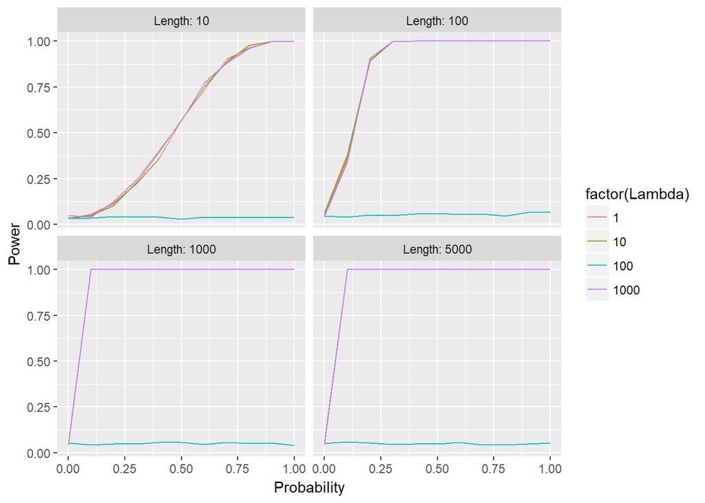

Powyższe wykresy pokazują, że wraz ze wzrostem **Propablity** moc testu wrasta co oznacza, że im bardziej dwie testowane próbki różnią się od siebie tym częstszym werdyktem jest odrzucenie hipotezy głównej (mediany próbek są istotnie różne).  
Jak można zauważyć, gdy **lambda** równa jest 100 (czyli tyle ile statyczna próbka) moc testu jest w miarę na stałym, niskim poziome, co spowodowane jest tym, że mediany dwóch rozkładów o tych samych lambdach nie są istotnie różne.  
Zwięszkanie **Length** niweluje błąd losowy, dzięki czemu wykresy z dłuższą próbą są dokładniejsze.